# Part II - Insights from Prosper Loan Data

by **Abdellatif Shtayeh**

## Investigation Overview

This presentation aims to highlight key trends and relationships in the Prosper Loan Data, focusing on loan performance, borrower rates, and borrower characteristics. The goal is to provide clear, actionable insights for stakeholders.

**Executive Summary:**

## Dataset Overview and Executive Summary

The Prosper Loan Data dataset includes 113,937 loans with 81 variables, such as loan amount, borrower rate, loan status, and borrower income. This analysis distills the data into key findings:

1. Borrower rates peak around 0.15-0.20.
2. Higher rates correlate with defaults.
3. Prosper rating effectively indicates loan risk.

```python
# Import packages and set plots to be embedded inline
import numpy as np
import pandas as pd
import matplotlib.pyplot as plt
import seaborn as sns
%matplotlib inline

# Suppress warnings
import warnings
warnings.simplefilter('ignore')

# Load the dataset
df = pd.read_csv('Data/prosperLoanData.csv')

# Define the order for LoanStatus
loan_status_order = ['Current', 'Completed', 'FinalPaymentInProgress', 'Past Due (1-15 days)', 'Past Due (16-30 days)', 'Past Due (31-60 days)', 'Past Due (61-90 days)', 'Past Due (91-120 days)', 'Chargedoff', 'Default']

# Convert LoanStatus to ordered categorical type
df['LoanStatus'] = pd.Categorical(df['LoanStatus'], categories=loan_status_order, ordered=True)
```

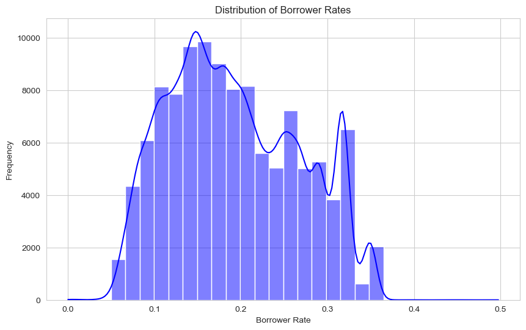

```python
# Visualization 1: Histogram of Borrower Rate
plt.figure(figsize=(10, 6))
sns.histplot(df['BorrowerRate'], bins=30, kde=True, color='blue')
plt.title('Distribution of Borrower Rates')
plt.xlabel('Borrower Rate')
plt.ylabel('Frequency')
plt.show()
```

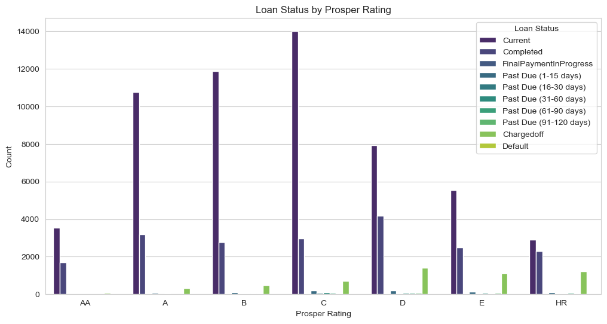

```python
# Visualization 2: Clustered Bar Chart of Prosper Rating and Loan Status (from Part I)
plt.figure(figsize=(12, 6))
sns.countplot(data=df, x='ProsperRating (Alpha)', hue='LoanStatus', order=['AA', 'A', 'B', 'C', 'D', 'E', 'HR'], palette='viridis')
plt.title('Loan Status by Prosper Rating')
plt.xlabel('Prosper Rating')
plt.ylabel('Count')
plt.legend(title='Loan Status')
plt.show()
```

**Comment:** Higher Prosper ratings (AA, A, B) show fewer defaults, while lower ratings (E, HR) have more, demonstrating the rating system's reliability in assessing risk.

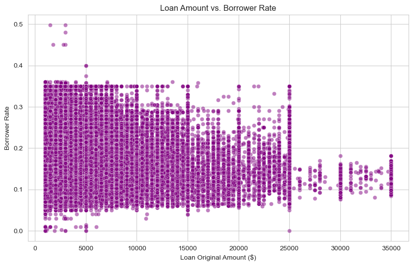

```python
# Visualization 3: Scatter Plot of Loan Amount vs. Borrower Rate (from Part I)
plt.figure(figsize=(10, 6))
sns.scatterplot(data=df, x='LoanOriginalAmount', y='BorrowerRate', alpha=0.5, color='purple')
plt.title('Loan Amount vs. Borrower Rate')
plt.xlabel('Loan Original Amount ($)')
plt.ylabel('Borrower Rate')
plt.show()
```

**Comment:** A slight negative correlation exists, suggesting that larger loans tend to have lower borrower rates, possibly due to better creditworthiness.